# Reproducible Research: Peer Assessment 1.SM

Sunjay M.

March 29, 2016

# Loading and preprocessing the data

##### Load the data (i.e. read.csv())

```r
setwd("~/R/Data Sets/Reproducible Research") #Set working Directory with the data set
dir() # to verify the files located in the directory and that it has the accurate data set
```

```
## [1] "activity.csv"        "PA1.1_template.html" "PA1.1_template.Rmd"
## [4] "PA1_template.md"     "PA1_template.Rmd"
```

##### Load the necessary packages that will be useful throughtout analysis and plotting

```r
library(ggplot2)
library(plyr)
```

#### Read in the Data from directory and classify the data to create consistency.

```r
activity <- read.csv("activity.csv", colClass=c('integer', 'Date', 'integer'))
str(activity) ##To see the data set's variables, observations, and first few values in the columns.
```

```
## 'data.frame':    17568 obs. of  3 variables:
##  $ steps   : int  NA NA NA NA NA NA NA NA NA NA ...
##  $ date    : Date, format: "2012-10-01" "2012-10-01" ...
##  $ interval: int  0 5 10 15 20 25 30 35 40 45 ...
```

#### Process/transform the data (if necessary) into a format suitable for your analysis

```r
activity$date <- as.Date(activity$date) #convert the date colum
activity$Day <- activity$Day <-weekdays(as.Date(activity$date)) #To seperate out dataset into difderent days according to the dates for analysis down the road.
activity$DateTime <- as.POSIXct(activity$date, format = "%Y-%m-%d")
CleanSteps <- activity[!is.na(activity$steps), ] ##Helps to remove the NA values in the steps column
```

## What is mean total number of steps taken per day?

#### Calculate the total number of steps taken per day

```r
SumSteps <- aggregate(activity$steps ~ activity$date, FUN = sum, )
colnames(SumSteps) <- c("Date", "Steps") #Renaming columns in new subset date to create histogram
```

#### Plotting the Histogram to display thee total steps per day

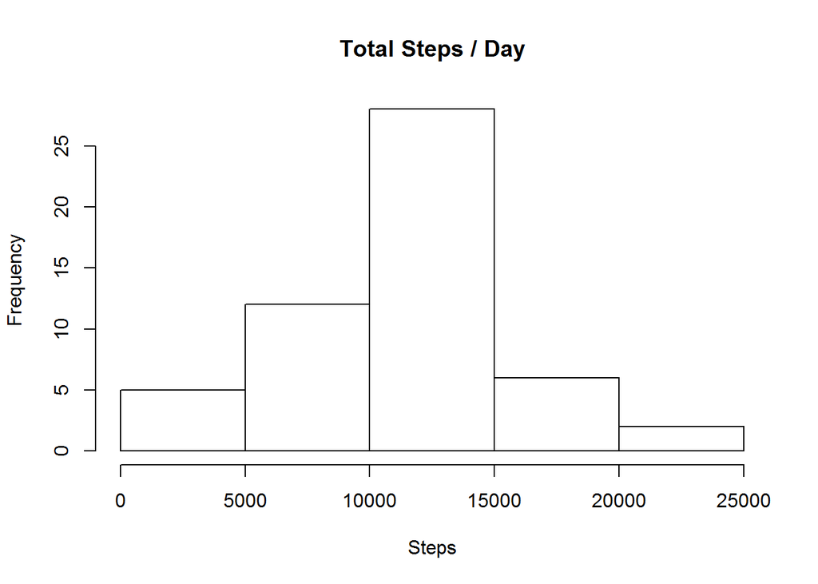

```r
hist(SumSteps$Steps, xlab = "Steps", main = "Total Steps / Day")
```

#### To identify the mean of steps taken per day, just run the calculation for mean in R

```r
mean(SumSteps$Steps)
```

```
## [1] 10766.19
```

```r
as.integer(mean(SumSteps$Steps)) #this is to provide a whole number of steps taken per day.
```

```
## [1] 10766
```

#### To identify the median of steps taken per day, just run the calculation for median in R

```r
median(SumSteps$Steps)
```

```
## [1] 10765
```

```r
as.integer(median(SumSteps$Steps))
```

```
## [1] 10765
```

# What is the average daily activity pattern?

##### Make a time series plot (i.e. type = “l”) of the 5-minute interval (x-axis) and the average number of steps taken, averaged across all days (y-axis)

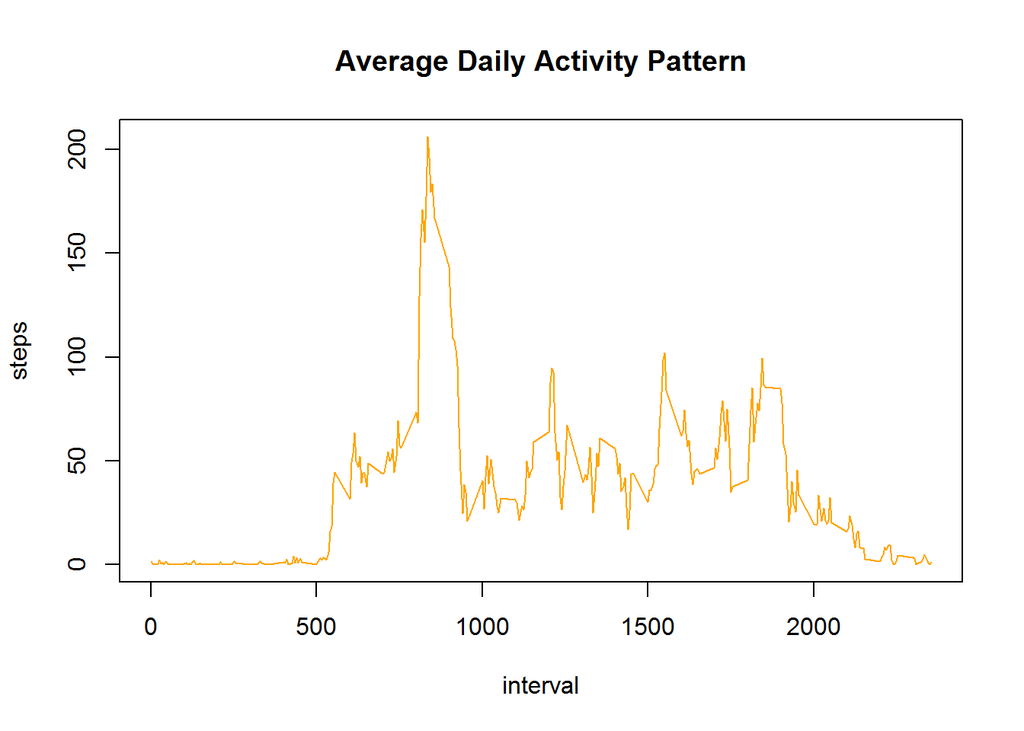

```r
StepsInter <- aggregate(steps ~ interval, activity, mean)
plot(StepsInter, type= "l", col="orange", main= "Average Daily Activity Pattern")
```

##### Calculate 5-minute interval containing the maximum number of steps

```r
StepsInter$interval[which.max(StepsInter$steps)]
```

```
## [1] 835
```

# Imputing missing values

##### Calculate and report the total number of missing values in the dataset (i.e. the total number of rows with NAs)

```r
sum(is.na(activity$steps))
```

```
## [1] 2304
```

##### Devise a strategy for filling in all of the missing values in the dataset.

```r
avgTable <- ddply(CleanSteps, .(interval, Day), summarize, Avg = mean(steps))
```

##### Create dataset with all NAs for substitution

```r
NAdata<- activity[is.na(activity$steps),]
```

##### Merge NA data with average weekday interval for substitution

```r
NewData<-merge(NAdata, avgTable, by=c("interval", "Day"))
```

##### Reorder the new substituded data in the same format as clean data set

```r
NewData2<- NewData[,c(6,4,1,2,5)]
colnames(NewData2)<- c("steps", "date", "interval", "Day", "DateTime")
```

##### Merge the NA averages and non NA data together

```r
MergeData <- rbind(CleanSteps, NewData2)
```

##### Create sum of steps per date to compare with step 1

```r
SumSteps2 <- aggregate(MergeData$steps ~ MergeData$date, FUN=sum, )
colnames(SumSteps2)<- c("Date", "Steps")
```

##### Mean number of Steps with NA data taken care of and returning a whole number

```r
as.integer(mean(SumSteps2$Steps))
```

```
## [1] 10821
```

##### Median of Steps with NA data taken care of and returning a whole number

```r
as.integer(median(SumSteps2$Steps))
```

```
## [1] 11015
```

#### Creating the histogram of total steps per day, categorized by data set to show impact of including the missing values

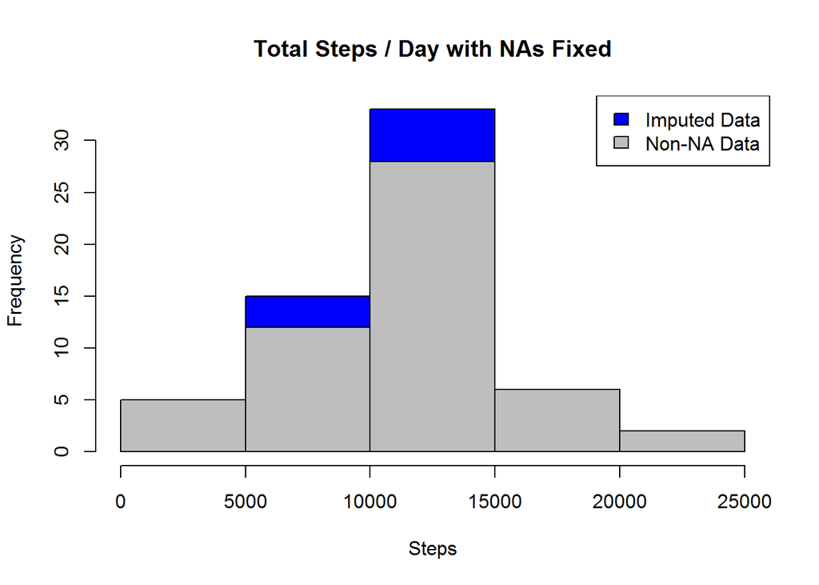

```r
hist(SumSteps2$Steps, breaks=5, xlab="Steps", main = "Total Steps / Day with NAs Fixed", col="Blue")
hist(SumSteps$Steps, breaks=5, xlab="Steps", main = "Total Steps / Day with NAs Fixed", col="Grey", add=T)
legend("topright", c("Imputed Data", "Non-NA Data"), fill=c("blue", "grey"))
```

# Are there differences in activity patterns between weekdays and weekends?

##### Create a new column to create a Weekday or Weekend depending on day of week

```r
MergeData$TypofDay <- ifelse(MergeData$Day %in% c("Saturday", "Sunday"), "Weekend", "Weekday")
```

```r
library(lattice)
```

##### Create new dataset to consolidate the data by the interval and the type of day in the week

```r
StepsInter2 <- ddply(MergeData, .(interval, TypofDay), summarize, Avg = mean(steps))
```

##### Plot

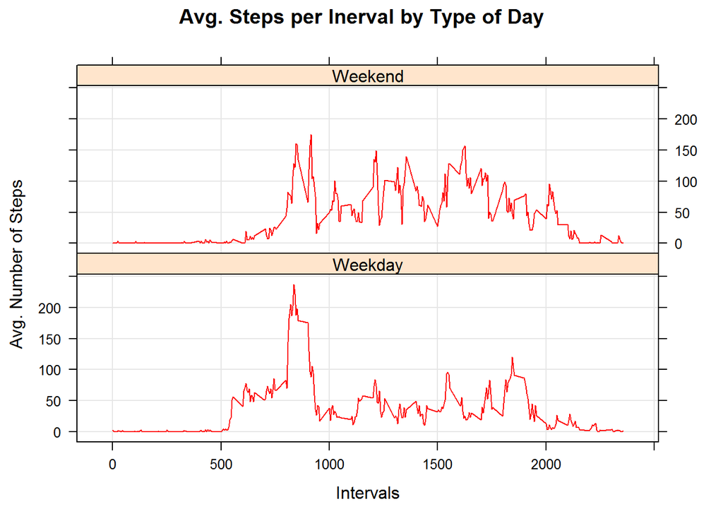

```r
xyplot(Avg~interval | TypofDay, data= StepsInter2, type = "l", layout = c(1,2), col = "red", grid = TRUE,
       main= "Avg. Steps per Inerval by Type of Day",
       ylab= "Avg. Number of Steps",
       xlab= "Intervals")
```